# A_pilot_1

Matt Green

This document aims to be a complete and up to date record of the analysis for vagueness 0, the pilot experiment.

The pilot experiment used subitizable numbers as well as bigger numbers. The instructions had the form: *Choose the square with {{few, many},{two, three, four, five, six, seven, eight, nine}} dots.* The variables were: subitizability; vagueness; target_size; gap_size; side (i.e., which side was the bigger number on?)

# Libraries and functions

Load libraries.

```r
library(knitr)
library(tidyverse)
library(broom)
library(dotwhisker)
library(grid)
library(gridExtra)
library(lme4)
# R CMD INSTALL broom.mixed # https://github.com/bbolker/broom.mixed
```

Source additional R files with functions for computing confidence intervals.

```r
source("CIfunctions.R") # for summarySEwithin etc
```

# Data

Get the data.

```r
# make the data file from the individual subjects' data unless it's already there in the directory
if (!file.exists("data.txt")) {
  system("echo 'gap\ttarget\tside\tvagueness\tpair\tVersion\tLeft\tRight\tText\tCondition\tcorrectAnswer\tsubject\tactualAnswer\tisCorrect\trt' > data.txt")
  system("cat ../experimentCode/output/*.dat >> data.txt", wait=TRUE)
}

# read in the data from file
din <- read_delim("data.txt", delim="\t")

# make an R object copy of that original data file
original_data <- din

# add observation number for the whole data set
din$obs <- 1:nrow(din)

# add trial index for each subject
din$trial <- 0
for (s in unique(din$subject)){
  din[din$subject==s, "trial"] <- 1:nrow(subset(din,subject==s))
}
```

```r
# make a df to carry forward
d <- tibble(
  obs = din$obs,
  trial = din$trial,
  subject = as.factor(din$subject),
  item = factor(din$pair, label = c("2:4", "3:5", "6:8", "7:9", "2:6", "7:3", "8:4", "5:9")),
  gap = factor(din$gap, levels = c("BigGap", "SmallGap"), labels = c("Big Gap", "Small Gap")),
  quan = factor(din$target, levels = c("BigTarget", "SmallTarget"), labels = c("Big Target", "Small Target")),
  vag = factor(din$vagueness, levels = c("Precise", "Vague"), labels = c("Crisp", "Vague")),
  subit = factor(ifelse(din$pair %in% c(1,2,5,6), "Subitizable", "Not subitizable")),
  side = factor(din$side),
  text = factor(din$Text),
  err = 1 - din$isCorrect,
  rt_ms = din$rt,
  rt_log = log( din$rt ),
  rt_reciprocal = -1/din$rt # rate of slowing: # We multiplied reciprocal scores [1/RT] by -1 [-1/RT] to maintain the direction of effects compatible for the three variants, effectively converting speed [number of responses per ms] into 'rate of slowing' - A linear mixed model analysis of masked repetition priming, Kliegl, Masson & Richter, VISUAL COGNITION,2010,18(5),655--681 (p.~662)
)
d$c.gap   <- ifelse(d$gap=="Big Gap", -.5, .5)
d$c.quan  <- ifelse(d$quan=="Big Target", -.5, .5)
d$c.vag   <- ifelse(d$vag=="Crisp", -.5, .5)
d$c.subit <- ifelse(d$subit=="Subitizable", -.5, .5)
d$c.side  <- ifelse(d$side=="Left", -.5, .5)
```

Size of the data is 1600 trials. There are 40 error trials. Error trials are removed from analysis of RT

```r
d <- subset(d, err==0)
```

## Eyeball the RTs

### Untrimmed

Notice min is -6; max in 20258.

```
##    Min. 1st Qu.  Median    Mean 3rd Qu.    Max.
##      -6    1024    1304    1643    1876   20258
```

### Trimmed at 0 ms and 10,000 ms

```
##    Min. 1st Qu.  Median    Mean 3rd Qu.    Max.
##     563    1024    1302    1620    1874    8271
```

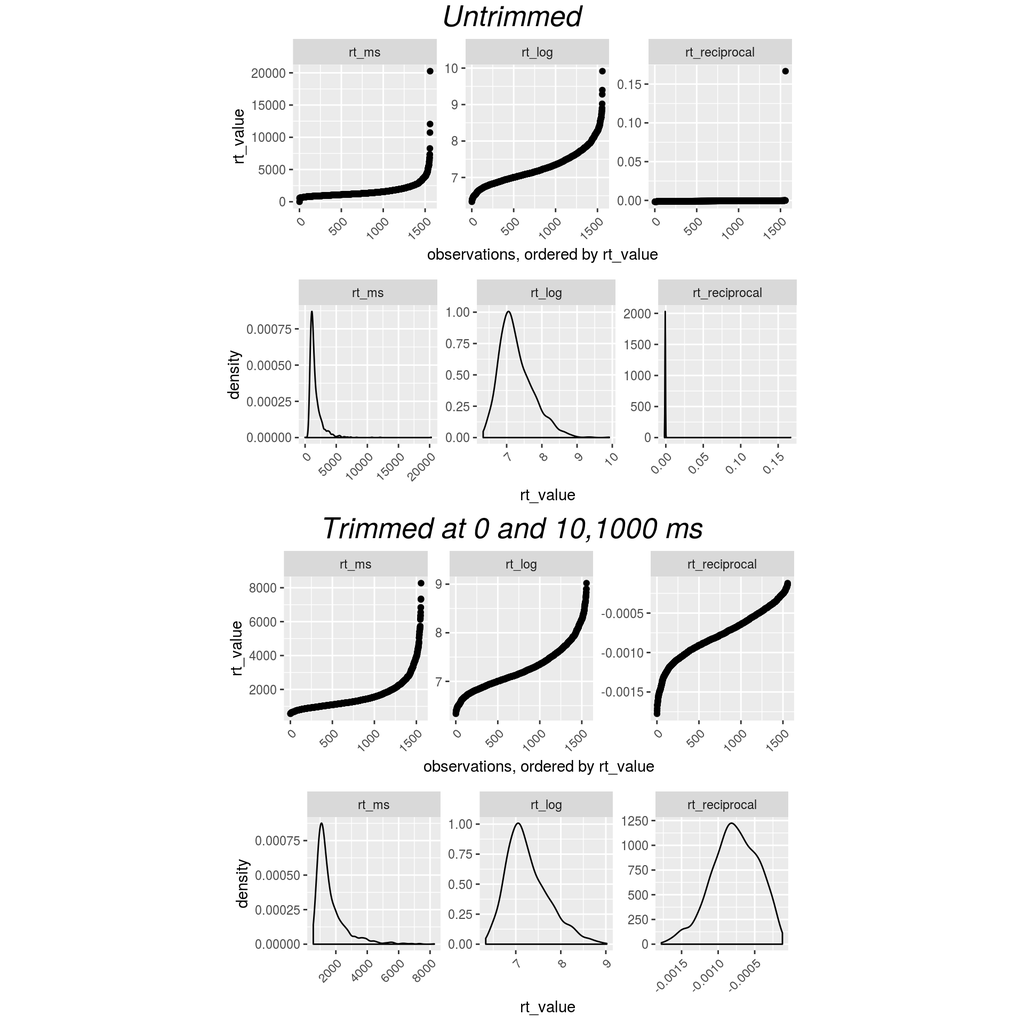

Select either trimmed or untrimmed data by comparing this plot with the untrimmed data. Also use this plot to choose the most normal data (logRT).

```r
dat <- d %>% filter(rt_ms >= 0 & rt_ms <= 10000)
```

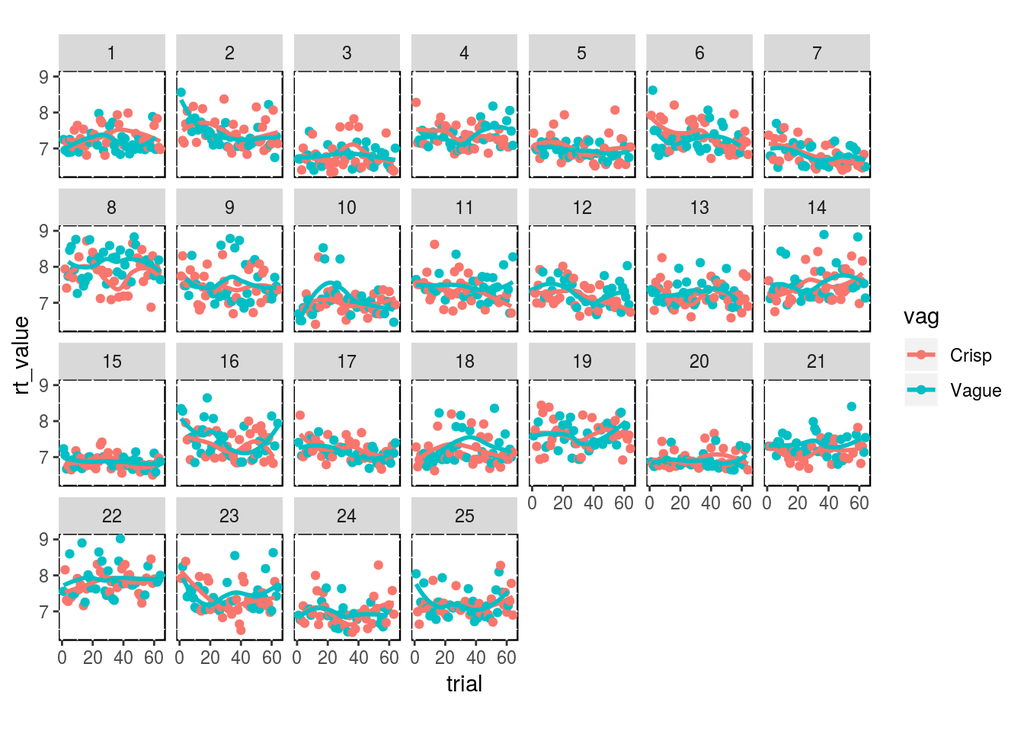

```r
dat %>%
  gather(key=rt_metric, value=rt_value, rt_ms, rt_log, rt_reciprocal) %>%
  filter(rt_metric=="rt_log") %>%
  ggplot(aes(x=trial, y=rt_value, col=vag)) +
  geom_point() +
  geom_smooth(se=F) +
  facet_wrap(~subject, ncol = 7) +
  theme(aspect.ratio = 1, panel.background = element_rect(fill="white", colour="black", linetype = "solid"))
```

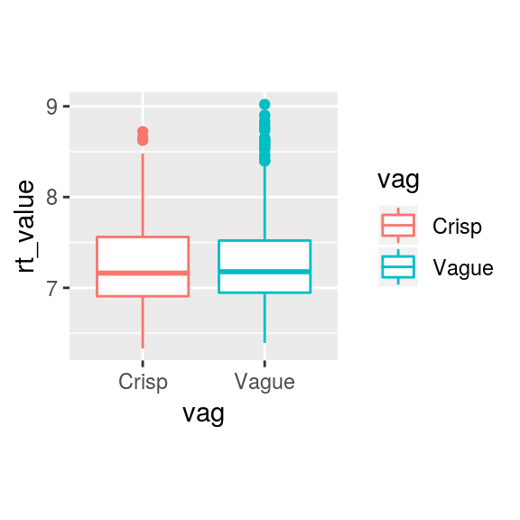

```r
dat %>%
  gather(key=rt_metric, value=rt_value, rt_ms, rt_log, rt_reciprocal) %>%
  filter(rt_metric=="rt_log") %>%
  ggplot(aes(group=vag, y=rt_value)) +
  geom_boxplot(aes(x=vag, col=vag)) +
  theme(aspect.ratio=1)
```

# RT modelling

Do a first lmer model. You can’t put subit or gap over items because they are between-items.

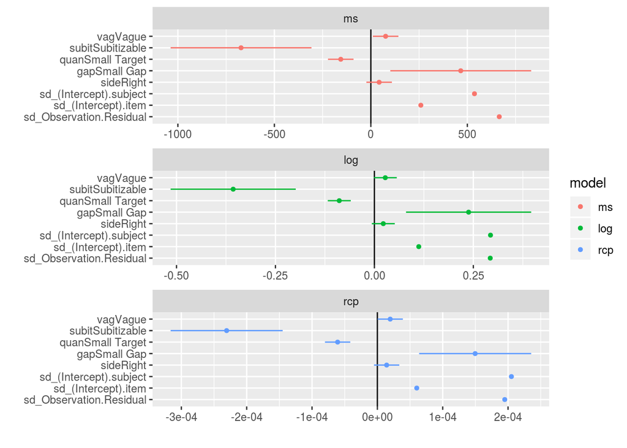

```r
lmer1.ms  <- lmer(data=dat, rt_ms ~         vag + subit + quan + gap + side + (1|subject) + (1|item))
lmer1.log <- lmer(data=dat, rt_log ~        vag + subit + quan + gap + side + (1|subject) + (1|item))
lmer1.rcp <- lmer(data=dat, rt_reciprocal ~ vag + subit + quan + gap + side + (1|subject) + (1|item))

models <-
rbind(
  cbind(tidy(lmer1.ms),model="ms"),
  cbind(tidy(lmer1.log),model="log"),
  cbind(tidy(lmer1.rcp),model="rcp")
)

dwplot(models, vline = geom_vline(xintercept = 0)) + facet_wrap(~model, scales="free", ncol=1)
```

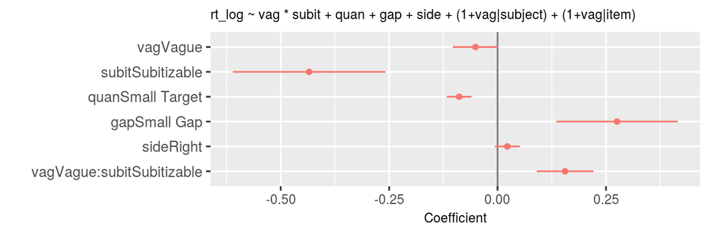

```r
lmer2.log <- lmer(data=dat, rt_log ~ vag * subit + quan + gap + side + (1+vag|subject) + (1+vag|item))

dwplot(lmer2.log %>% tidy() %>% filter(group=="fixed"), vline = geom_vline(xintercept = 0, colour = "grey50", linetype = 1)) +
  xlab("Coefficient") +
  ggtitle("rt_log ~ vag * subit + quan + gap + side + (1+vag|subject) + (1+vag|item)") +
  theme(plot.title = element_text(size = 8), axis.title.x = element_text(size=8), axis.text.x = element_text(size=8))
```

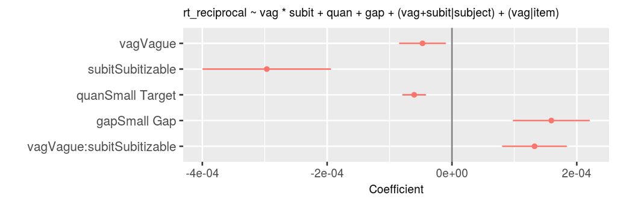

```r
lmer2.rcp <- lmer(data=dat, rt_reciprocal~subit*vag + (vag|subject) + (vag|item))

# lmer3 is closer to the original anova than lmer2
lmer3 <- lmer(data=dat, rt_reciprocal~vag*subit+quan+gap + (vag+subit|subject) + (vag|item))

dwplot(lmer3 %>% tidy() %>% filter(group=="fixed"), vline = geom_vline(xintercept = 0, colour = "grey50", linetype = 1)) +
  xlab("Coefficient") +
  ggtitle("rt_reciprocal ~ vag * subit + quan + gap + (vag+subit|subject) + (vag|item)") +
  theme(plot.title = element_text(size = 8), axis.title.x = element_text(size=8), axis.text.x = element_text(size=8))
```